# Final Project: QuickDraw!

Lacey Etzkorn

11/16/2018

## Motivation and Overview:

**Provide an overview of the project goals and the motivation for it. Consider that this will be read by people who did not see your project proposal.**

Google’s internet game QuickDraw prompts players to draw a given object. Such objects include an apple, a kangaroo, or the Eiffel Tower. You can play the game here: https://quickdraw.withgoogle.com. As the player draws the object, Google attempts to guess what the user is drawing. In fact, Google uses user-supplied doodles to train an object recognition algorithm. Google has released some of the doodle data, and has opened up a Kaggle competition for teams to submit their own algorithms.

The goal of competing teams is to produce an algorithm that classifies doodles in a test set with the lowest mean average precision. Kaggle defines the mean average precision as follows:

$$\text{MAP}@3 = \sum_{u=1}^U \sum_{k=1}^{\min(n,3)} P(k)$$
where “$U$ is the number of scored drawings in the test data, $P(k)$ is the precision at cutoff $k$, and $n$ is the number predictions per drawing.”

## Data:

**What is the data source? Document the data import, wrangling, etc.**

Data was downloaded from the Kaggle website. The website provided two types of data: a raw version and a simplified version that had been pre-processed. We chose to use the pre-processed data so we could focus on the methods.

##### Figure 1: A Doodle from each Food Class

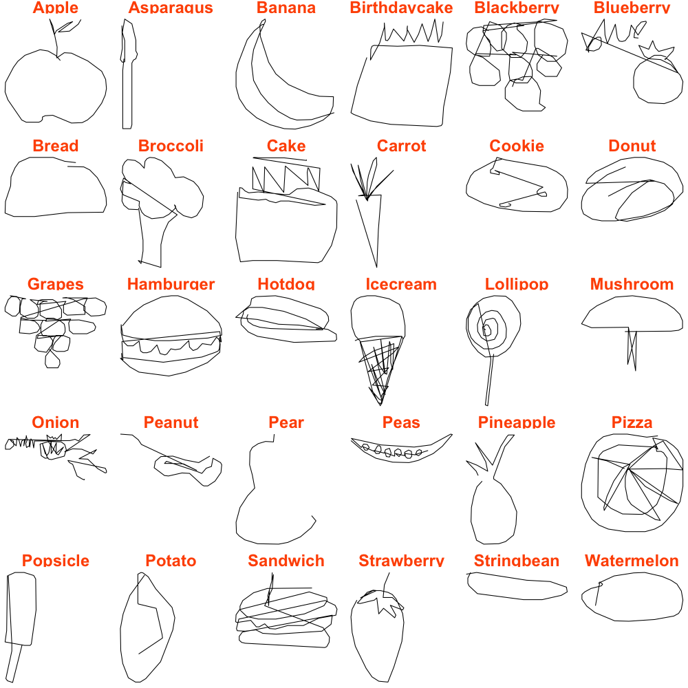

For each drawing class, we only used 6,000 images from the simplified data set. We allocated 5,000 images from each class to train our model and 1,000 images to test our model.